# ExtraaLearn Project

## Model Performance evaluation and improvement

### **Decision Tree - Hyperparameter Tuning**

We will use the class_weight hyperparameter with the value equal to {0: 0.3, 1: 0.7} which is approximately the opposite of the imbalance in the original data.

**This would tell the model that 1 is the important class here.**

```python
# Choose the type of classifier
d_tree_tuned = DecisionTreeClassifier(random_state=7, class_weight={0: 0.3, 1: 0.7})

# Grid of parameters to choose from
parameters = {'max_depth': np.arange(2, 10),
              'criterion': ['gini', 'entropy'],
              'min_samples_leaf': [5, 10, 20, 25]
             }

# Type of scoring used to compare parameter combinations - recall score for class 1
scorer = make_scorer(recall_score, pos_label=1)

# Run the grid search
grid_obj = GridSearchCV(d_tree_tuned, parameters, scoring=scorer, cv=5)
grid_obj = grid_obj.fit(X_train, y_train)

# Set the classifier to the best combination of parameters
d_tree_tuned = grid_obj.best_estimator_

# Fit the best algorithm to the data
d_tree_tuned.fit(X_train, y_train)
```

```
DecisionTreeClassifier(class_weight={0: 0.3, 1: 0.7}, criterion='entropy',
                       max_depth=3, min_samples_leaf=5, random_state=7)
```

We have tuned the model and fit the tuned model on the training data. Now, **let's check the model performance on the training and testing data.**

```
              precision    recall  f1-score   support

           0       0.94      0.77      0.85      2273
           1       0.62      0.88      0.73       955

    accuracy                           0.80      3228
   macro avg       0.78      0.83      0.79      3228
weighted avg       0.84      0.80      0.81      3228
```

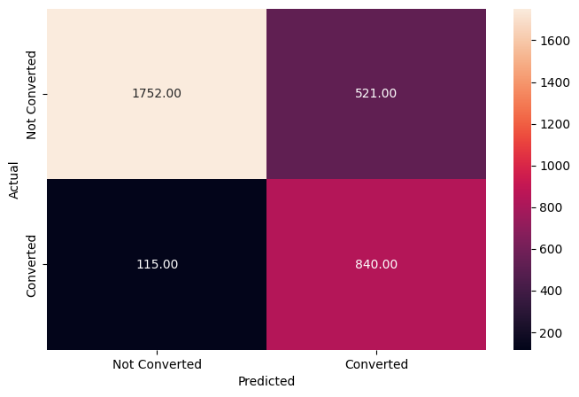

```python
# Checking performance on the training data
y_pred_train2 = d_tree_tuned.predict(X_train)

# Evaluate the performance on the training data
metrics_score(y_train, y_pred_train2)
```

**Observations:**

- The tuned Decision Tree model demonstrates **improved recall for the converted leads (Class 1)** on the training data, which is a positive outcome. The trade-off is a **decrease in precision for Class 1**, indicating a higher risk of false positives. This shift in the balance may be acceptable depending on the business goals.

```
              precision    recall  f1-score   support

           0       0.93      0.77      0.84       962
           1       0.62      0.86      0.72       422

    accuracy                           0.80      1384
   macro avg       0.77      0.82      0.78      1384
weighted avg       0.83      0.80      0.80      1384
```

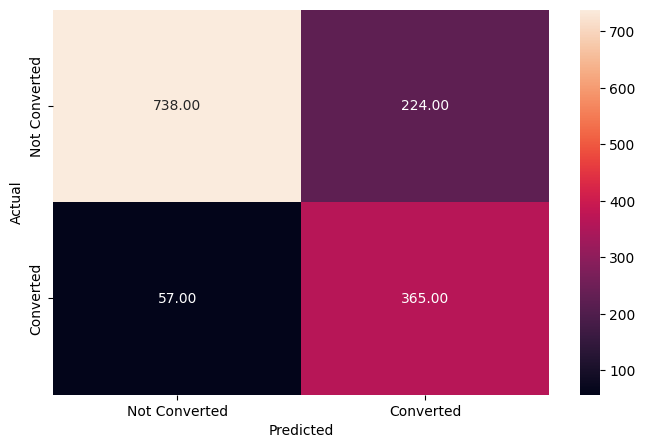

```python
# Checking performance on the testing data
y_pred_test2 = d_tree_tuned.predict(X_test)

# Evaluate the performance on the testing data
metrics_score(y_test, y_pred_test2)
```

**Observations:**

- The tuned Decision Tree model demonstrates **improved recall for the converted leads (Class 1)** on the training data, which is a positive outcome. The trade-off is a **decrease in precision for Class 1**, indicating a higher risk of false positives. This shift in the balance may be acceptable depending on the business goals.
- The Recall on the test data suggests that there's a 14% (1 - 0.86) chance that the model will predict that a person is NOT going be converted even though he/she would be converted, and **the company may lose a valuable lead.**

### Visualizing the Decision Tree

**Let's visualize the tuned decision tree** and observe the decision rules:

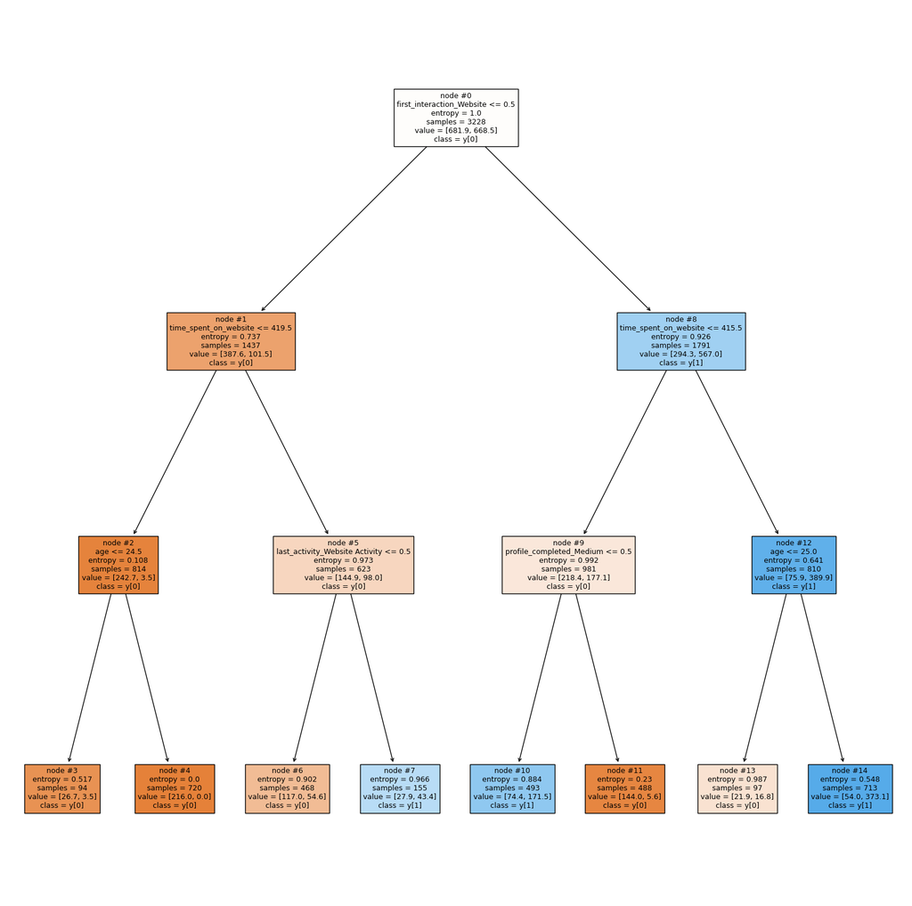

```python
# Import necessary libraries
from sklearn.tree import plot_tree
import matplotlib.pyplot as plt

# Get the list of feature names
features = list(X.columns)

# Set the size of the plot
plt.figure(figsize = (20, 20))

# Plot the decision tree using plot_tree
tree.plot_tree(d_tree_tuned, feature_names = features, filled = True, fontsize = 9, node_ids = True, class_names = True)

# Display the plot
plt.show()
```

**Note:** Blue leaves represent the converted leads, i.e., **y[1]**, while the orange leaves represent the not converted leads, i.e., **y[0]**. Also, the more the number of observations in a leaf, the darker its color gets.

**Observations:**

- Leads who had their first interaction via website, spend more than 415min on the website, have more than 25 years old have more likilihood to be converted.
- Leads who had NO first interaction via website, spend less than 419min on the website, have less than 24.5 years old have less likilihood to be converted.
- `Last_activity_website` also seems to have a positive relationship in predicting if a lead is likely to be converted.

**Let's look at the feature importance** of the tuned decision tree model

```python
# Importance of features in the tree building

print (pd.DataFrame(d_tree_tuned.feature_importances_, columns = ["Imp"], index = X_train.columns).sort_values(by = 'Imp', ascending = False))
```

```
                                   Imp
time_spent_on_website          0.34814
first_interaction_Website      0.32718
profile_completed_Medium       0.23927
age                            0.06389
last_activity_Website Activity 0.02151
website_visits                 0.00000
page_views_per_visit           0.00000
current_occupation_Student     0.00000
current_occupation_Unemployed  0.00000
profile_completed_Low          0.00000
last_activity_Phone Activity   0.00000
print_media_type1_Yes          0.00000
print_media_type2_Yes          0.00000
digital_media_Yes              0.00000
educational_channels_Yes       0.00000
referral_Yes                   0.00000
```

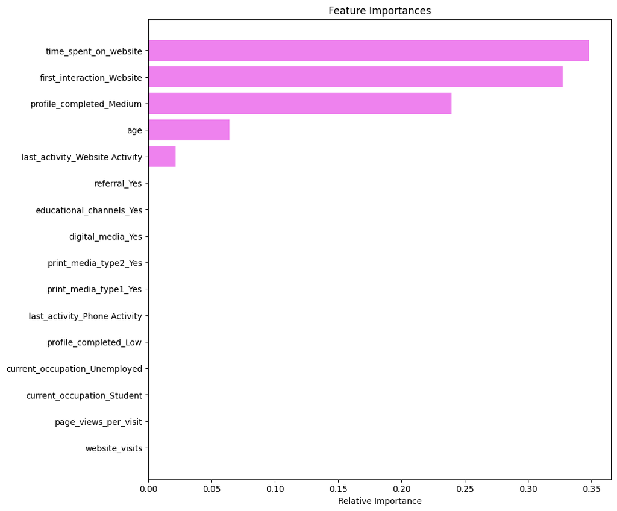

```python
# Plotting the feature importance
importances = d_tree_tuned.feature_importances_

indices = np.argsort(importances)

plt.figure(figsize = (10, 10))

plt.title('Feature Importances')

plt.barh(range(len(indices)), importances[indices], color = 'violet', align = 'center')

plt.yticks(range(len(indices)), [features[i] for i in indices])

plt.xlabel('Relative Importance')

plt.show()
```

**Observations:**

- After tuning the model, we are getting that only 5 features are important. It seems like **the model is having some bias**, as it has over-simplified the problem and is not capturing the patterns associated with other variables.
- According to this model too, `Time_spend_on_website`, `First_interaction_website`, `Profile_completed_medium`, `age`, and `Last_activity_website` are the 5 most important features that describe why a lead is converted, which might imply that website leads may have a better buy experience and then the marketing efforts could be directed to them.

## Building a Random Forest model

```python
# Choose the number of estimators (trees) based on your requirements
n_estimators = 100  # You can adjust this number

# Create the Random Forest classifier
rf_estimator = RandomForestClassifier(n_estimators=n_estimators, random_state=42, class_weight={0: 0.3, 1: 0.7})

# Fit the Random Forest classifier to the training data
rf_estimator.fit(X_train, y_train)
```

```
RandomForestClassifier(class_weight={0: 0.3, 1: 0.7}, random_state=42)
```

```
              precision    recall  f1-score   support

           0       1.00      1.00      1.00      2273
           1       1.00      1.00      1.00       955

    accuracy                           1.00      3228
   macro avg       1.00      1.00      1.00      3228
weighted avg       1.00      1.00      1.00      3228
```

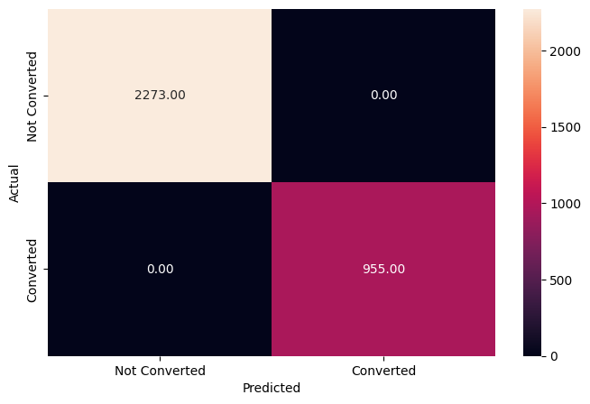

```python
# Checking performance on the training data
y_pred_train3 = rf_estimator.predict(X_train)

# Evaluate the performance on the training data
metrics_score(y_train, y_pred_train3)
```

**Observation:**

- The Random Forest is giving a **100% score for all metrics on the training dataset.**

```
              precision    recall  f1-score   support

           0       0.87      0.93      0.90       962
           1       0.80      0.68      0.73       422

    accuracy                           0.85      1384
   macro avg       0.83      0.80      0.81      1384
weighted avg       0.85      0.85      0.85      1384
```

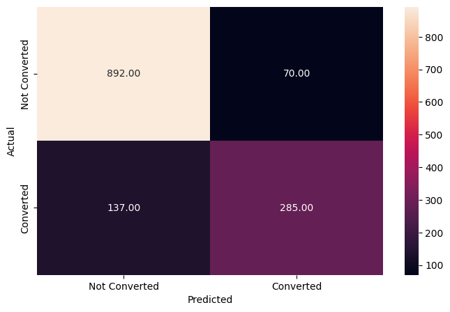

```python
# Checking performance on the testing data
y_pred_test3 = rf_estimator.predict(X_test)

# Evaluate the performance on the testing data
metrics_score(y_test, y_pred_test3)
```

**Observations:**

- The Random Forest classifier **seems to be overfitting the training data**. The recall on the training data is 1, while the recall on the test data is only ~ 0.68 for class 1.
- Precision is higher in the initial Random forest model than in decision tree model; however, Recall on the test data suggests that there's a 32% (1 - 0.68) chance that the model will predict that a person is NOT going be converted even though he/she would be converted, and **the company may lose a valuable lead.**

## Model Performance evaluation and improvement

### **Random Forest Classifier - Hyperparameter Tuning**

Let's try **tuning some of the important hyperparameters of the Random Forest Classifier**.

We will **not** tune the `criterion` hyperparameter as we know from hyperparameter tuning for decision trees that `entropy` is a better splitting criterion for this data.

```python
from sklearn.ensemble import RandomForestClassifier
from sklearn.model_selection import GridSearchCV

# Choose the type of classifier
rf_estimator_tuned = RandomForestClassifier(criterion="entropy", random_state=7)

# Grid of parameters to choose from
parameters = {
    "n_estimators": [110, 120],
    "max_depth": [6, 7],
    "min_samples_leaf": [20, 25],
    "max_features": [0.8, 0.9],
    "max_samples": [0.9, 1],
    "class_weight": ["balanced", {0: 0.3, 1: 0.7}]
}

# Type of scoring used to compare parameter combinations - recall score for class 1
scorer = metrics.make_scorer(recall_score, pos_label=1)

# Run the grid search on the training data using scorer=scorer and cv=5
grid_obj = GridSearchCV(
    estimator=rf_estimator_tuned,
    param_grid=parameters,
    scoring=scorer,
    cv=5
)

grid_obj = grid_obj.fit(X_train, y_train)

# Save the best estimator to variable rf_estimator_tuned
rf_estimator_tuned = grid_obj.best_estimator_

# Fit the best estimator to the training data
rf_estimator_tuned.fit(X_train, y_train)
```

```
RandomForestClassifier(class_weight='balanced', criterion='entropy',
                       max_depth=6, max_features=0.8, max_samples=0.9,
                       min_samples_leaf=25, n_estimators=120, random_state=7)
```

```
              precision    recall  f1-score   support

           0       0.94      0.83      0.88      2273
           1       0.68      0.87      0.76       955

    accuracy                           0.84      3228
   macro avg       0.81      0.85      0.82      3228
weighted avg       0.86      0.84      0.84      3228
```

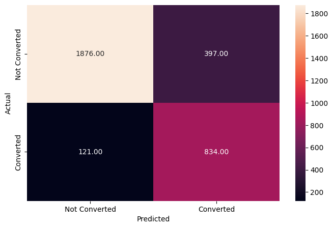

```python
# Checking performance on the training data
y_pred_train4 = rf_estimator_tuned.predict(X_train)

# Evaluate the performance on the training data
metrics_score(y_train, y_pred_train4)
```

```
              precision    recall  f1-score   support

           0       0.93      0.83      0.87       962
           1       0.68      0.85      0.76       422

    accuracy                           0.83      1384
   macro avg       0.81      0.84      0.82      1384
weighted avg       0.85      0.83      0.84      1384
```

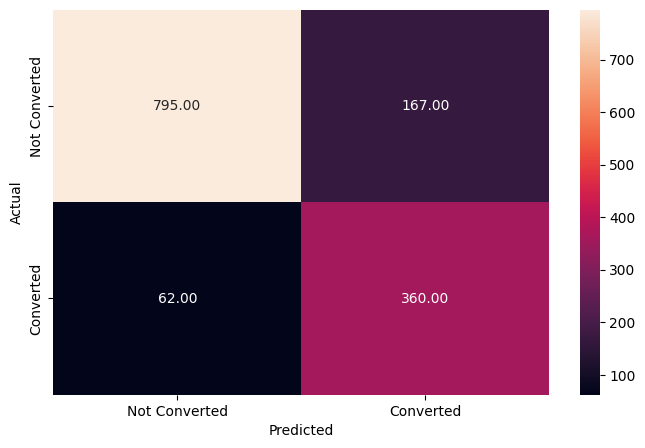

```python
# Checking performance on the test data
y_pred_test4 = rf_estimator_tuned.predict(X_test)

# Evaluate the performance on the test data
metrics_score(y_test, y_pred_test4)
```

**Observations:**

**One of the drawbacks of ensemble models is that we lose the ability to obtain an interpretation of the model. We cannot observe the decision rules for random forests the way we did for decision trees. So, let's just check the feature importance of the model.**

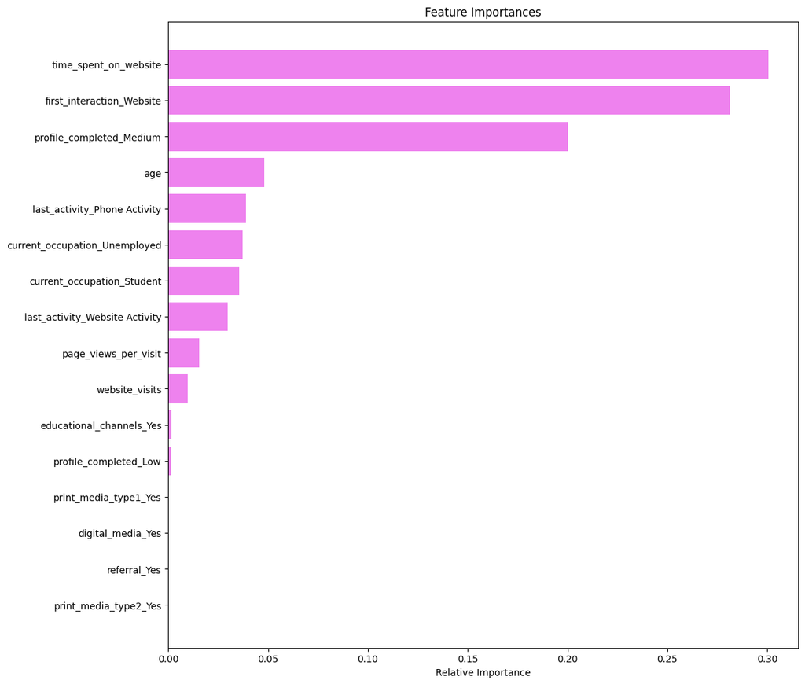

```python
# Get feature importances from a tuned Random Forest estimator (rf_estimator_tuned)
importances = rf_estimator_tuned.feature_importances_

# Sort the indices of importances in ascending order
indices = np.argsort(importances)

# Get the names of the features from the input data (X)
feature_names = list(X.columns)

# Create a horizontal bar plot to visualize feature importances
plt.figure(figsize=(12, 12))

# Set the title of the plot
plt.title('Feature Importances')

# Plot horizontal bars with the relative importance of each feature
plt.barh(range(len(indices)), importances[indices], color='violet', align='center')

# Set y-axis ticks with feature names based on the sorted indices
plt.yticks(range(len(indices)), [feature_names[i] for i in indices])

# Label for x-axis
plt.xlabel('Relative Importance')

# Display the plot
plt.show()
```

**Observations:**

- The Random Forest further verifies the results from the decision tree that the most important features are `time_spend_website`, `firstinteraction_website`, `Profile_completed_Medium` and `age`.
- We can say that the people appear to be buying the courses when the marketing interaction is view website and they are more than 25 years old, so they are able to pay for the course.
- Current_ocupation_student has also some importance, sutdents could be focused on finishing their degrees and therefore they could have less interest in ExtraLearn programs.
- Other features such as last activity phone and current acupation unemployed also play a crucial role in knowing whether a lead will be converted or not.

## **Additional Optimization**

## **Boosting Models**

Let's now look at the other kind of Ensemble technique knowns as Boosting

### **XGBoost**

- XGBoost stands for Extreme Gradient Boosting.
- XGBoost is a tree-based ensemble machine learning technique that improves prediction power and performance by improvising on the Gradient Boosting framework and incorporating reliable approximation algorithms. It is widely utilized and routinely appears at the top of competition leader boards in data science.

```python
# Installing the xgboost library using the 'pip' command.
!pip install xgboost
```

```python
# Importing the AdaBoostClassifier and GradientBoostingClassifier [Boosting]
from sklearn.ensemble import AdaBoostClassifier, GradientBoostingClassifier

# Importing the XGBClassifier from the xgboost library
from xgboost import XGBClassifier
```

Let’s try Adaboost Classifier, Gradient Boost Classifier and XGBoost Classifier with original weights and with modified weights {0: 0.3, 1: 0.7}

# Adaboost Classifier

```
              precision    recall  f1-score   support

           0       0.91      0.79      0.85       962
           1       0.63      0.81      0.71       422

    accuracy                           0.80      1384
   macro avg       0.77      0.80      0.78      1384
weighted avg       0.82      0.80      0.80      1384
```

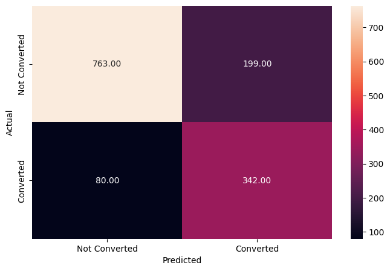

```python
from sklearn.metrics import accuracy_score, classification_report, confusion_matrix

# Adaboost Classifier
y_pred_adaboost = adaboost_model.predict(X_test)

# Evaluate performance
accuracy = accuracy_score(y_test, y_pred_adaboost)
conf_matrix = confusion_matrix(y_test, y_pred_adaboost)
class_report = classification_report(y_test, y_pred_adaboost)

# Make predictions on the test set
y_pred_adaboost = adaboost_model.predict(X_test)

# Evaluate performance using your metrics_score function
metrics_score(y_test, y_pred_adaboost)
```

**Observations:**

- **The Adaboost Classifier with original weights model does not improve the recall results.**

```
              precision    recall  f1-score   support

           0       0.91      0.79      0.85       962
           1       0.63      0.81      0.71       422

    accuracy                           0.80      1384
   macro avg       0.77      0.80      0.78      1384
weighted avg       0.82      0.80      0.80      1384
```

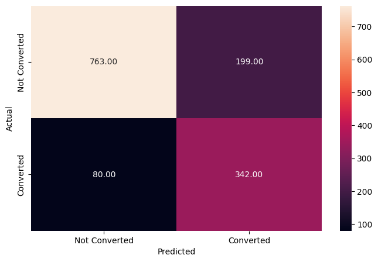

```python
from sklearn.ensemble import AdaBoostClassifier
from sklearn.metrics import accuracy_score, classification_report, confusion_matrix

# Specify the class weights
class_weights = {0: 0.3, 1: 0.7}

# Create AdaBoost Classifier
adaboost_model = AdaBoostClassifier()

# Set sample weights based on class weights
sample_weights = np.array([class_weights[y] for y in y_train])

# Fit the model with sample weights
adaboost_model.fit(X_train, y_train, sample_weight=sample_weights)

# Make predictions on the test set
y_pred_adaboost = adaboost_model.predict(X_test)

# Evaluate performance
accuracy = accuracy_score(y_test, y_pred_adaboost)
conf_matrix = confusion_matrix(y_test, y_pred_adaboost)
class_report = classification_report(y_test, y_pred_adaboost)

# Make predictions on the test set
y_pred_adaboost = adaboost_model.predict(X_test)

# Evaluate performance using your metrics_score function
metrics_score(y_test, y_pred_adaboost)
```

**Observations:**

- **The Adaboost Classifier with modified weights model does not improve the recall results.**

# Gradient Boost Classifier

```
              precision    recall  f1-score   support

           0       0.94      0.84      0.89       962
           1       0.71      0.87      0.78       422

    accuracy                           0.85      1384
   macro avg       0.82      0.86      0.83      1384
weighted avg       0.87      0.85      0.85      1384
```

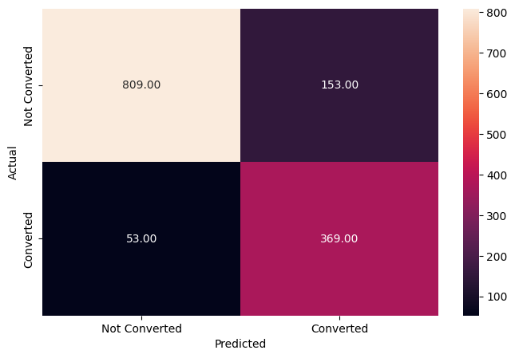

```python
from sklearn.metrics import accuracy_score, classification_report, confusion_matrix

# Gradient Boost Classifier
y_pred_gbc = gbc.predict(X_test)

# Evaluate performance
accuracy = accuracy_score(y_test, y_pred_gbc)
conf_matrix = confusion_matrix(y_test, y_pred_gbc)
class_report = classification_report(y_test, y_pred_gbc)

# Make predictions on the test set
y_pred_gbc = gbc.predict(X_test)

# Evaluate performance using your metrics_score function
metrics_score(y_test, y_pred_gbc)
```

**Observations:**

```
              precision    recall  f1-score   support

           0       0.94      0.84      0.89       962
           1       0.71      0.87      0.78       422

    accuracy                           0.85      1384
   macro avg       0.82      0.86      0.83      1384
weighted avg       0.87      0.85      0.85      1384
```

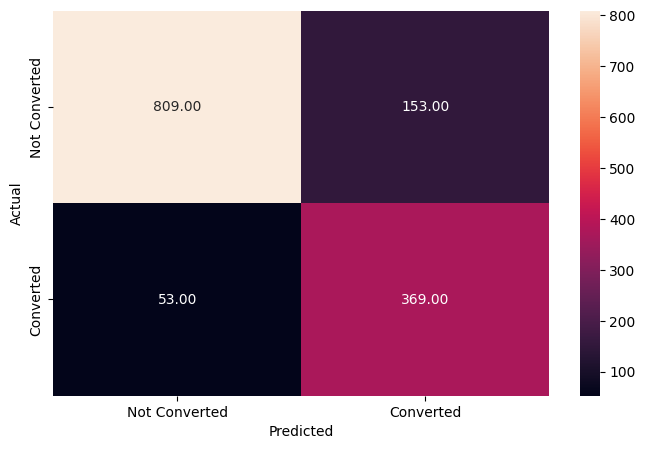

```python
from sklearn.ensemble import GradientBoostingClassifier
from sklearn.metrics import accuracy_score, classification_report, confusion_matrix

# Specify the class weights
class_weights = {"balanced": None, 0: 0.3, 1: 0.7}

# Create Gradient Boosting Classifier
gbc = GradientBoostingClassifier()

# Set sample weights based on class weights
sample_weights = np.array([class_weights[y] for y in y_train])

# Fit the model with sample weights
gbc.fit(X_train, y_train, sample_weight=sample_weights)

# Make predictions on the test set
y_pred_gbc_mw = gbc.predict(X_test)

# Evaluate performance
accuracy = accuracy_score(y_test, y_pred_gbc_mw)
conf_matrix = confusion_matrix(y_test, y_pred_gbc_mw)
class_report = classification_report(y_test, y_pred_gbc_mw)

# Make predictions on the test set
y_pred_gbc_mw = gbc.predict(X_test)

# Evaluate performance using your metrics_score function
metrics_score(y_test, y_pred_gbc_mw)
```

**Observations:**

- **The Gradient Boost Classifier model with modified weights improves the recall results to 0.87 for class 1.**
- **Additionally, The Gradient Boost Classifier model with modified weights has a high f1-score for class 1: 0.78 and for class 0 :0.89. These results are better than the Tuned decision tree which has f1-score for class 1: 0.72 and for class 0 :0.84**

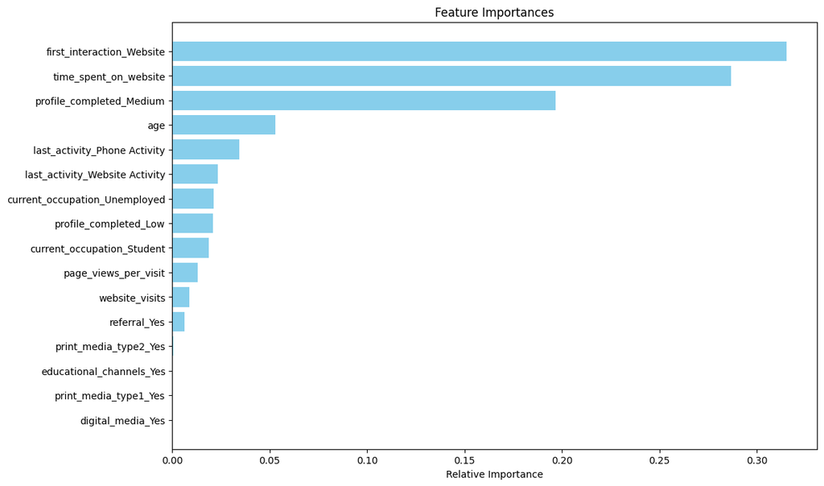

```python
import matplotlib.pyplot as plt

# Extract feature importances
importances = gbc.feature_importances_

# Sort indices based on importance
indices = np.argsort(importances)

# Create a horizontal bar plot
plt.figure(figsize=(12, 8))
plt.barh(range(len(indices)), importances[indices], color='skyblue', align='center')
plt.yticks(range(len(indices)), [X.columns[i] for i in indices])
plt.xlabel('Relative Importance')
plt.title('Feature Importances')
plt.show()
```

**Observations:**

- The Gradient Boost Classifier model with modified weights further verifies the results from the decision tree and Tuned Random forest that the most important features are `firstinteraction_website`, `time_spend_website`, `Profile_completed_Medium` and `age`.
- We can say that the people appear to be buying the courses when the marketing interaction is via website, and they are more than 25 years old perhaps older people are able to pay for the course easily.
- Current_ocupation_student also has some importance; students could focus on finishing their degrees and therefore they could have less interest in ExtraLearn programs.
- Other features such as last activity phone, last activity website and current occupation unemployed also play a crucial role in knowing whether a lead will be converted or not.

# XGBoost Classifier

```
              precision    recall  f1-score   support

           0       0.88      0.92      0.90       962
           1       0.79      0.71      0.75       422

    accuracy                           0.85      1384
   macro avg       0.83      0.81      0.82      1384
weighted avg       0.85      0.85      0.85      1384
```

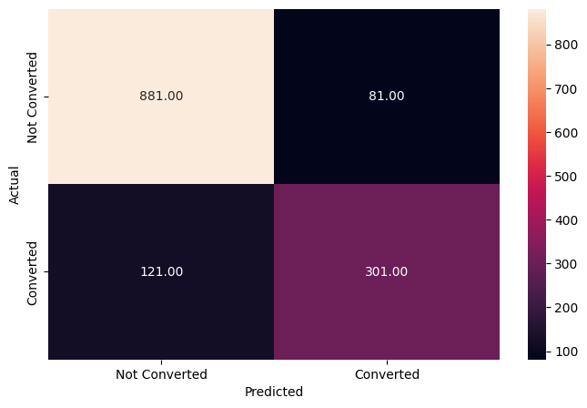

```python
from xgboost import XGBClassifier
from sklearn.metrics import accuracy_score, classification_report, confusion_matrix

# XGBoost Classifier
xgb = XGBClassifier(random_state=1, eval_metric='logloss')

# Fitting the model
xgb.fit(X_train, y_train)

# Model Performance on the test data
y_pred_xgb = xgb.predict(X_test)

# Calculate and print metrics
accuracy = accuracy_score(y_test, y_pred_xgb)
conf_matrix = confusion_matrix(y_test, y_pred_xgb)
class_report = classification_report(y_test, y_pred_xgb)

# Model Performance on the test data
y_pred_xgb = xgb.predict(X_test)

# Evaluate performance using your metrics_score function
metrics_score(y_test, y_pred_xgb)
```

```
              precision    recall  f1-score   support

           0       0.87      0.92      0.89       962
           1       0.79      0.68      0.73       422

    accuracy                           0.85      1384
   macro avg       0.83      0.80      0.81      1384
weighted avg       0.84      0.85      0.84      1384
```

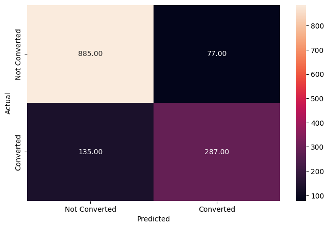

```python
from xgboost import XGBClassifier
from sklearn.metrics import accuracy_score, classification_report, confusion_matrix

# Specify the class weights
class_weights = {0: 0.3, 1: 0.7}

# Create XGBoost Classifier
xgb = XGBClassifier(random_state=1, eval_metric='logloss', scale_pos_weight=class_weights[1])

# Fitting the model
xgb.fit(X_train, y_train)

# Model Performance on the test data
y_pred_xgb = xgb.predict(X_test)

# Calculate and print metrics
accuracy = accuracy_score(y_test, y_pred_xgb)
conf_matrix = confusion_matrix(y_test, y_pred_xgb)
class_report = classification_report(y_test, y_pred_xgb)

# Model Performance on the test data
y_pred_xgb = xgb.predict(X_test)

# Evaluate performance using your metrics_score function
metrics_score(y_test, y_pred_xgb)
```

**Observations:**

- **The XGBoost model does not improve the recall results.**

**Observations on Boosting Models:**

- **The Gradient Boost Classifier model with modified weights improves the recall results to 0.87 for class 1.**
- **The Gradient Boost Classifier and The Tuned decision tree models give the best performance for this dataset with a recall of 0.87, and 0.86 respectively.**
- **Additionally, The Gradient Boost Classifier model with modified weights has a high f1-score for class 1: 0.78 and for class 0 :0.89. These results are better than the Tuned decision tree which has f1-score for class 1: 0.72 and for class 0 :0.84.**

## Actionable Insights and Recommendations

## **Conclusion**

- The best model we have got so far is the Gradient Boost Classifier model with modified weights which is giving nearly ~ 87% recall for class 1 on the test data.
- The company should use this model to know beforehand which lead is going to be converted and act accordingly.
- `firstinteraction_website`, `time_spend_website`, `Profile_completed_Medium` and `age`seem to be the most important features.
- The overall lead conversion rate is 29.9%, which provides a baseline to compare against.
- Leads who first interact via the website have significantly higher conversion rates (45.6%) compared to mobile app (10.5%). Focusing marketing and resources on driving more website traffic could improve overall conversion.
- Time spent on the website is highly correlated with conversion, with converted leads spending a median of 789 mins vs 317 mins for non-converts. Keeping leads engaged onsite longer should increase conversion likelihood.

## **Recommendations**

- Since time spent on the website emerged as the most important factor in predicting lead conversion, ExtraLearn should prioritize marketing strategies that engage visitors and extend their website session lengths:
  1. Optimize site architecture and navigation to make it easy for visitors to find relevant content and navigate to related topics/pages. This encourages further exploration.
  2. Implement advanced tracking analytics to identify popular site content as well as pages with high exit rates. Refine or enhance high-interest areas; modify or remove content that fails to engage.
  3. Integrate interactive elements like assessments, quizzes, calculators, etc. that lead visitors to spend more time providing information relevant to course matching.
  4. Retarget visitors via ads/email campaigns who leave the site before hitting key engagement thresholds personalized to vertical/offering. Remind them of content still to explore.
  5. Test modular course content samples accessible to visitors without requiring lead forms upfront. This demonstrates value from courses before asking for visitor info.

  The core focus should be providing sticky website experiences tailored to visitor vertical/persona that drive session times upward and subsequently increase the likelihood of lead conversion. An integrated analytics and testing framework will enable iterating on the most effective engagement strategies over time.
- Given the goal is to maximize conversion of potential customers, continue using the Gradient Boosting model in production to score incoming leads. Use the lead scores to focus sales efforts on those most likely to convert.
- Put additional resources into the website experience, features, content etc to drive longer session times. This has a direct impact on conversion.
- Analyze what web pages and content converts spend more time on and identify opportunities to better engage them during the session.
- Establish feedback loops to continually collect data on new leads, retrain models periodically, and improve conversion performance over time.
- Set up A/B testing frameworks to test changes to web pages, outreach campaigns, pricing models etc. and their impact on conversion rates.